# Homework 4

```r
rpart.preds<-ifelse(rpart.preds.prob>0.5,"fraud","non_fraud")
conf.mat<-confusionMatrix(table(rpart.preds,test_credit$Y))
print(conf.mat)
```

```
## Confusion Matrix and Statistics
##
##
## rpart.preds fraud non_fraud
##   fraud        24         2
##   non_fraud     7      1497
##
##                Accuracy : 0.9941
##                  95% CI : (0.9889, 0.9973)
##     No Information Rate : 0.9797
##     P-Value [Acc > NIR] : 2.953e-06
##
##                   Kappa : 0.8391
##
##  Mcnemar's Test P-Value : 0.1824
##
##             Sensitivity : 0.77419
##             Specificity : 0.99867
##          Pos Pred Value : 0.92308
##          Neg Pred Value : 0.99535
##              Prevalence : 0.02026
##          Detection Rate : 0.01569
##    Detection Prevalence : 0.01699
##       Balanced Accuracy : 0.88643
##
##        'Positive' Class : fraud
##
```

```r
rpart.perf<-conf.mat$byClass["Balanced Accuracy"]
print(rpart.perf)
```

```
## Balanced Accuracy
##         0.8864297
```

3. Random Forest

```r
sqrt(ncol(Traindat)) # mtry is selected around this value
```

```
## [1] 5.477226
```

```r
Grid.Matrix= expand.grid(mtry=c(3,4,5,6,7,8))
control.param$allowParallel<-T
cl <- makeCluster(8)
registerDoSNOW(cl)
set.seed(123)
fit.rf <- caret::train(x = Traindat ,
                       y = TrainResponse,
                       method = "rf",
                       trControl = control.param,
                       tuneGrid = Grid.Matrix,
                       metric="Balanced_Accuracy",
                       ntree=500,
                       nodesize=5)
stopCluster(cl)

print(fit.rf)
```

```
## Random Forest
##
## 3570 samples
##   30 predictor
##    2 classes: 'fraud', 'non_fraud'
##
## No pre-processing
## Resampling: Cross-Validated (10 fold)
## Summary of sample sizes: 3213, 3213, 3212, 3213, 3213, 3213, ...
## Resampling results across tuning parameters:
##
##   mtry  logLoss     AUC        prAUC      Accuracy   Kappa      F1
##   3     0.04852474  0.9517302  0.5553502  0.9958007  0.8608549  0.8627972
##   4     0.05631325  0.9479709  0.5395536  0.9960808  0.8715787  0.8734033
##   5     0.06443740  0.9414586  0.5283893  0.9960808  0.8715787  0.8734033
##   6     0.05683664  0.9469105  0.5136879  0.9958014  0.8653593  0.8673427
##   7     0.06443636  0.9421747  0.5089319  0.9958014  0.8653593  0.8673427
##   8     0.06417304  0.9444821  0.4747982  0.9958014  0.8653593  0.8673427
##   Sensitivity  Specificity  Pos_Pred_Value  Neg_Pred_Value  Precision
##   0.7857143    1.0000000    1.00            0.9957531       1.00
##   0.8000000    1.0000000    1.00            0.9960348       1.00
##   0.8000000    1.0000000    1.00            0.9960348       1.00
##   0.8000000    0.9997151    0.98            0.9960324       0.98
##   0.8000000    0.9997151    0.98            0.9960324       0.98
##   0.8000000    0.9997151    0.98            0.9960324       0.98
##   Recall     Detection_Rate  Balanced_Accuracy
##   0.7857143  0.01512764      0.8928571
##   0.8000000  0.01540775      0.9000000
##   0.8000000  0.01540775      0.9000000
##   0.8000000  0.01540775      0.8998575
##   0.8000000  0.01540775      0.8998575
##   0.8000000  0.01540775      0.8998575
##
## Balanced_Accuracy was used to select the optimal model using the largest value.
## The final value used for the model was mtry = 4.
```

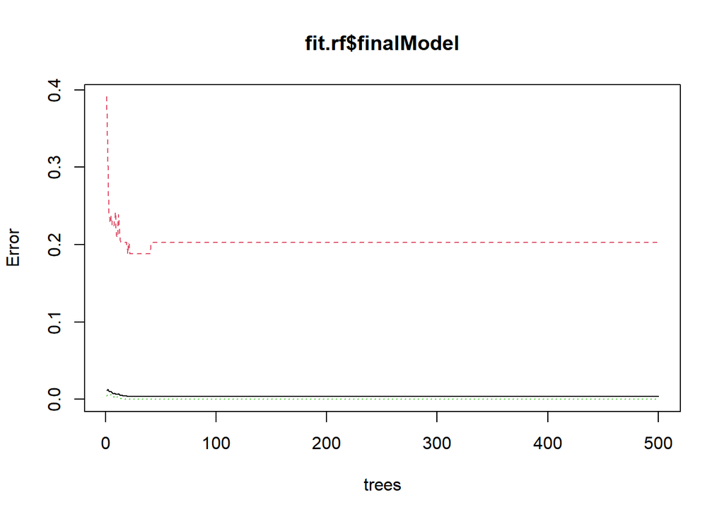

```r
plot(fit.rf$finalModel)
```

It looks like we are not overfitting. While training error decreases, test error also decreases and then increases a bit. Using 500 trees is not improving error rate. Using lower may be enough.

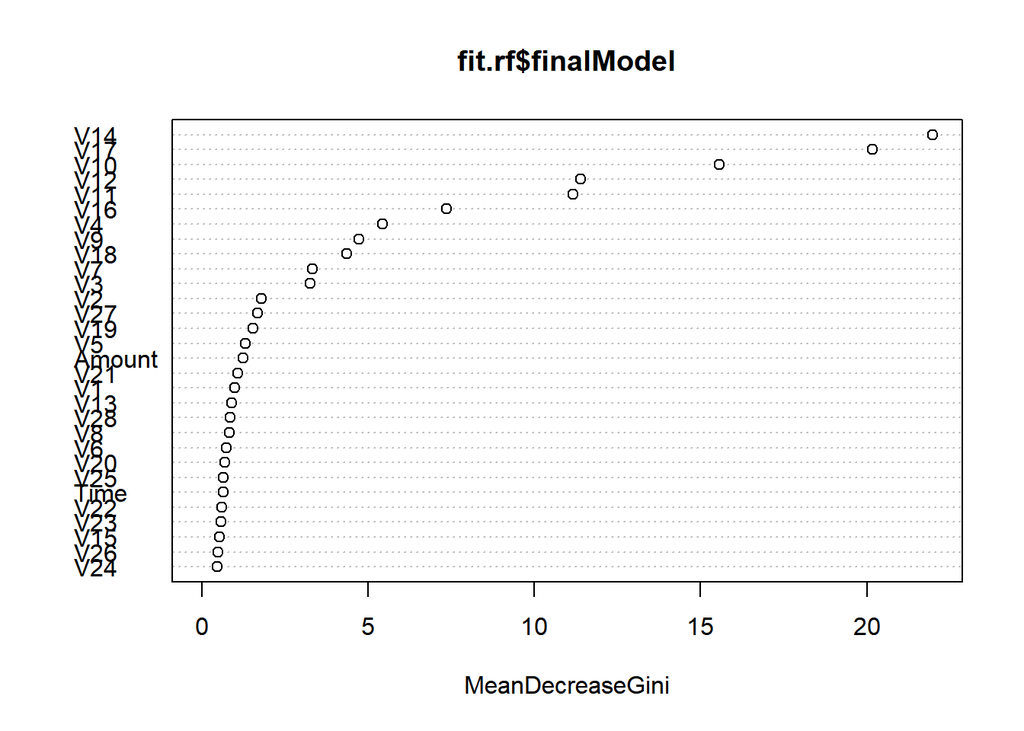

```r
varImpPlot(fit.rf$finalModel)
```

```r
imp<-data.frame(fit.rf$finalModel$importance,var = rownames(fit.rf$finalModel$importance))
imp %>% arrange(desc(MeanDecreaseGini)) %>%
  mutate(csum_gini=cumsum(MeanDecreaseGini)) %>%
  print()
```

```
##    MeanDecreaseGini    var csum_gini
## 1        21.9923303    V14  21.99233
## 2        20.1697318    V17  42.16206
## 3        15.5754791    V10  57.73754
## 4        11.4028240    V12  69.14037
## 5        11.1773899    V11  80.31776
## 6         7.3559480    V16  87.67370
## 7         5.4469204     V4  93.12062
## 8         4.7407813     V9  97.86140
## 9         4.3671403    V18 102.22855
## 10        3.3296628     V7 105.55821
## 11        3.2531066     V3 108.81131
## 12        1.7899261     V2 110.60124
## 13        1.6867001    V27 112.28794
## 14        1.5533717    V19 113.84131
```

[output cut: 16 more lines]

```r
#First 10 variables V17,V14,V12,V11 covers more than 50% of total gini decrease
```

```r
rf.preds.prob<-predict(fit.rf,test_credit,type = "prob")[,"fraud"]
for(thr in seq(0.1,0.7,by=0.2)){
  rf.preds<-ifelse(rf.preds.prob>thr,"fraud","non_fraud")
  conf.mat<-confusionMatrix(table(rf.preds,test_credit$Y))
  print(thr)
  print(conf.mat)
}
```

```
## [1] 0.1
## Confusion Matrix and Statistics
##
##
## rf.preds    fraud non_fraud
##   fraud        26        16
##   non_fraud     5      1483
##
##                Accuracy : 0.9863
##                  95% CI : (0.9791, 0.9915)
##     No Information Rate : 0.9797
##     P-Value [Acc > NIR] : 0.03653
##
##                   Kappa : 0.7055
##
##  Mcnemar's Test P-Value : 0.02910
##
##             Sensitivity : 0.83871
##             Specificity : 0.98933
##          Pos Pred Value : 0.61905
##          Neg Pred Value : 0.99664
##              Prevalence : 0.02026
##          Detection Rate : 0.01699
##    Detection Prevalence : 0.02745
##       Balanced Accuracy : 0.91402
##
##        'Positive' Class : fraud
##
## [1] 0.3
## Confusion Matrix and Statistics
##
##
## rf.preds    fraud non_fraud
##   fraud        25         3
##   non_fraud     6      1496
##
##                Accuracy : 0.9941
##                  95% CI : (0.9889, 0.9973)
##     No Information Rate : 0.9797
##     P-Value [Acc > NIR] : 2.953e-06
```

[output cut: 57 more lines]

```
##                   Kappa : 0.8273
##
##  Mcnemar's Test P-Value : 0.007661
##
##             Sensitivity : 0.70968
##             Specificity : 1.00000
##          Pos Pred Value : 1.00000
##          Neg Pred Value : 0.99403
##              Prevalence : 0.02026
##          Detection Rate : 0.01438
##    Detection Prevalence : 0.01438
##       Balanced Accuracy : 0.85484
##
##        'Positive' Class : fraud
##
```

```r
rf.preds<-ifelse(rf.preds.prob>0.5,"fraud","non_fraud")
conf.mat<-confusionMatrix(table(rf.preds,test_credit$Y))
print(conf.mat)
```

```
## Confusion Matrix and Statistics
##
##
## rf.preds    fraud non_fraud
##   fraud        24         0
##   non_fraud     7      1499
##
##                Accuracy : 0.9954
##                  95% CI : (0.9906, 0.9982)
##     No Information Rate : 0.9797
##     P-Value [Acc > NIR] : 1.979e-07
##
##                   Kappa : 0.8704
##
##  Mcnemar's Test P-Value : 0.02334
##
##             Sensitivity : 0.77419
##             Specificity : 1.00000
##          Pos Pred Value : 1.00000
##          Neg Pred Value : 0.99535
##              Prevalence : 0.02026
##          Detection Rate : 0.01569
##    Detection Prevalence : 0.01569
##       Balanced Accuracy : 0.88710
##
##        'Positive' Class : fraud
##
```

```r
# We marked 7 frauds as non frauds and we correctly classified all non frauds.

rf.perf<-conf.mat$byClass["Balanced Accuracy"]
print(rf.perf)
```

```
## Balanced Accuracy
##         0.8870968
```

By using lower threshold on probabilities we can find more frauds however, we will classify some non frauds as fraud. If we are not afraid of negative outcome of this choice then we can determine lower threshold.

4. Stochastic Gradient Boosting

```r
Grid.Matrix= expand.grid(n.trees=seq(20,300,length.out = 3),
                         interaction.depth=c(5,8,12),
                         shrinkage=c(0.01,0.03,0.05),
                         n.minobsinnode=c(10))
cl <- makeCluster(8)
registerDoSNOW(cl)
set.seed(123)
fit.gbm <- caret::train(x = Traindat ,
                        y = TrainResponse,
                        method = "gbm",
                        trControl = control.param,
                        tuneGrid = Grid.Matrix,
                        metric="Balanced_Accuracy")
stopCluster(cl)
print(fit.gbm)
```

```
## Stochastic Gradient Boosting
##
## 3570 samples
##   30 predictor
##    2 classes: 'fraud', 'non_fraud'
##
## No pre-processing
## Resampling: Cross-Validated (10 fold)
## Summary of sample sizes: 3213, 3213, 3212, 3213, 3213, 3213, ...
## Resampling results across tuning parameters:
##
##   shrinkage  interaction.depth  n.trees  logLoss     AUC        prAUC
##   0.01        5                  20      0.05771086  0.9360473  0.8339281
##   0.01        5                 160      0.02879186  0.9483789  0.8332602
##   0.01        5                 300      0.02615827  0.9495063  0.8404249
##   0.01        8                  20      0.05749501  0.9366015  0.8357227
##   0.01        8                 160      0.02904385  0.9463611  0.8472965
##   0.01        8                 300      0.02680657  0.9424059  0.8488351
##   0.01       12                  20      0.05727453  0.9304817  0.8462373
##   0.01       12                 160      0.02869343  0.9338513  0.8476324
##   0.01       12                 300      0.02661137  0.9477088  0.8504502
##   0.03        5                  20      0.04077159  0.9476257  0.8411534
##   0.03        5                 160      0.02845788  0.9496764  0.8454519
##   0.03        5                 300      0.03306096  0.9497768  0.8475540
##   0.03        8                  20      0.03951084  0.9337596  0.8486521
##   0.03        8                 160      0.02921286  0.9503280  0.8513750
##   0.03        8                 300      0.03771887  0.9548891  0.8506255
##   0.03       12                  20      0.04024461  0.9251129  0.8409689
##   0.03       12                 160      0.03004155  0.9450577  0.8490556
##   0.03       12                 300      0.04094548  0.9562452  0.8492760
##   0.05        5                  20      0.03366982  0.9231707  0.8334343
##   0.05        5                 160      0.03219085  0.9459394  0.8430196
##   0.05        5                 300      0.03791273  0.9504457  0.8497891
##   0.05        8                  20      0.03259123  0.9300093  0.8435898
##   0.05        8                 160      0.03604770  0.9472625  0.8491960
##   0.05        8                 300      0.05008451  0.9511133  0.8494866
##   0.05       12                  20      0.03359257  0.9254524  0.8373045
##   0.05       12                 160      0.03986364  0.9460160  0.8485597
##   0.05       12                 300      0.05785415  0.9543778  0.8511011
##   Accuracy   Kappa      F1         Sensitivity  Specificity  Pos_Pred_Value
```

[output cut: 45 more lines]

```
##   0.9960331       0.9486111  0.8000000  0.015407754     0.8994286
##   0.9946207       0.9833333  0.7285714  0.014007976     0.8641429
##   0.9960307       0.9286111  0.8000000  0.015407754     0.8992861
##   0.9960331       0.9708333  0.8000000  0.015407754     0.8997143
##   0.9951865       0.9800000  0.7571429  0.014568200     0.8784286
##   0.9960307       0.9383333  0.8000000  0.015407754     0.8994290
##   0.9960331       0.9388889  0.8000000  0.015407754     0.8992857
##   0.9951857       0.9675000  0.7571429  0.014567418     0.8782857
##   0.9960283       0.8961111  0.8000000  0.015407754     0.8990004
##   0.9960307       0.9286111  0.8000000  0.015407754     0.8992857
##
## Tuning parameter 'n.minobsinnode' was held constant at a value of 10
## Balanced_Accuracy was used to select the optimal model using the largest value.
## The final values used for the model were n.trees = 300, interaction.depth =
##  12, shrinkage = 0.01 and n.minobsinnode = 10.
```